# PCA

Otra forma de leer los archivos:

setwd(“C:/Users/Personal/Google Drive/MDCurso/Datos”) Datos <- read.table(‘EjemploEstudiantes.csv’, header=TRUE, sep=‘;’,dec=‘,’,row.names=1)

# Paquetes

```r
suppressMessages(library(FactoMineR)) # paquete para ACP
```

```r
library(ggplot2) # paquete por excelencia para graficas en R
library(corrplot) # graficar correlaciones
library(corrr) # correlaciones
library(ggcorrplot) # correlaciones
library(GGally) # para usar ggcorr
library(visdat) #para usar visdat y ver los tipos de variables
library(rattle) #Para usar hclust y calcular los centros para graficos de radar o araña
library(fmsb) # Paquete para usar radarchart
```

# Lectura de datos

```r
estudiantes <- read.csv("Datos/EjemploEstudiantes.csv", sep = ";", dec = ",", header = T,row.names = 1)
head(estudiantes)
```

|  | Matematicas | Ciencias | Espanol | Historia | EdFisica |
| --- | --- | --- | --- | --- | --- |
| Lucia | 7.0 | 6.5 | 9.2 | 8.6 | 8.0 |
| Pedro | 7.5 | 9.4 | 7.3 | 7.0 | 7.0 |
| Ines | 7.6 | 9.2 | 8.0 | 8.0 | 7.5 |
| Luis | 5.0 | 6.5 | 6.5 | 7.0 | 9.0 |
| Andres | 6.0 | 6.0 | 7.8 | 8.9 | 7.3 |
| Ana | 7.8 | 9.6 | 7.7 | 8.0 | 6.5 |

|  | Matematicas <dbl> | Ciencias <dbl> | Espanol <dbl> | Historia <dbl> | EdFisica <dbl> |
| --- | --- | --- | --- | --- | --- |
| Lucia | 7.0 | 6.5 | 9.2 | 8.6 | 8.0 |
| Pedro | 7.5 | 9.4 | 7.3 | 7.0 | 7.0 |
| Ines | 7.6 | 9.2 | 8.0 | 8.0 | 7.5 |
| Luis | 5.0 | 6.5 | 6.5 | 7.0 | 9.0 |
| Andres | 6.0 | 6.0 | 7.8 | 8.9 | 7.3 |
| Ana | 7.8 | 9.6 | 7.7 | 8.0 | 6.5 |

6 rows

```r
str(estudiantes)
```

```
## 'data.frame':    10 obs. of  5 variables:
##  $ Matematicas: num  7 7.5 7.6 5 6 7.8 6.3 7.9 6 6.8
##  $ Ciencias   : num  6.5 9.4 9.2 6.5 6 9.6 6.4 9.7 6 7.2
##  $ Espanol    : num  9.2 7.3 8 6.5 7.8 7.7 8.2 7.5 6.5 8.7
##  $ Historia   : num  8.6 7 8 7 8.9 8 9 8 5.5 9
##  $ EdFisica   : num  8 7 7.5 9 7.3 6.5 7.2 6 8.7 7
```

# Hagamos una exploración para ver las variables y las correlaciones entre ellas:

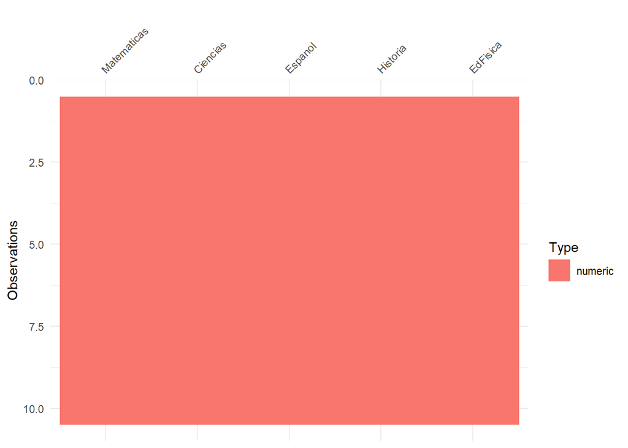

```r
vis_dat(estudiantes) # función para tipos de variables
```

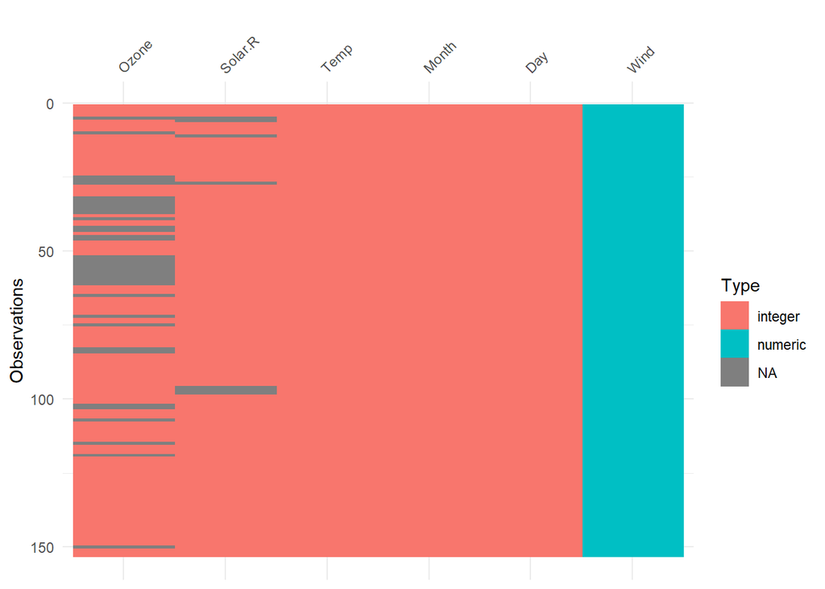

```r
# Vista de otro Dataset, donde hay más variedad de datos
data("airquality") # Dataset de R
vis_dat(airquality)
```

```r
# Para ver las correlaciones numéricas
c <- cor(estudiantes)
c
```

```
##             Matematicas    Ciencias     Espanol    Historia   EdFisica
## Matematicas   1.0000000  0.85407878  0.38457424  0.20719425 -0.7871627
## Ciencias      0.8540788  1.00000000 -0.02005218 -0.02153942 -0.6877206
## Espanol       0.3845742 -0.02005218  1.00000000  0.82091619 -0.3655434
## Historia      0.2071943 -0.02153942  0.82091619  1.00000000 -0.5080013
## EdFisica     -0.7871627 -0.68772056 -0.36554342 -0.50800132  1.0000000
```

```r
c <- round(cor(estudiantes), 2)
c
```

```
##             Matematicas Ciencias Espanol Historia EdFisica
## Matematicas        1.00     0.85    0.38     0.21    -0.79
## Ciencias           0.85     1.00   -0.02    -0.02    -0.69
## Espanol            0.38    -0.02    1.00     0.82    -0.37
## Historia           0.21    -0.02    0.82     1.00    -0.51
## EdFisica          -0.79    -0.69   -0.37    -0.51     1.00
```

```r
class(c)
```

```
## [1] "matrix"
```

# Explorando las correlaciones de los datos

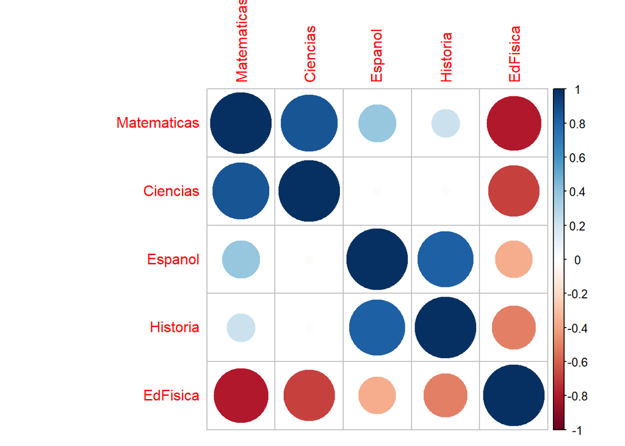

```r
# Revisemos algunas correlaciones

# Se trabaja con la matriz
corrplot(c) #requiere el paqeute corrplot
```

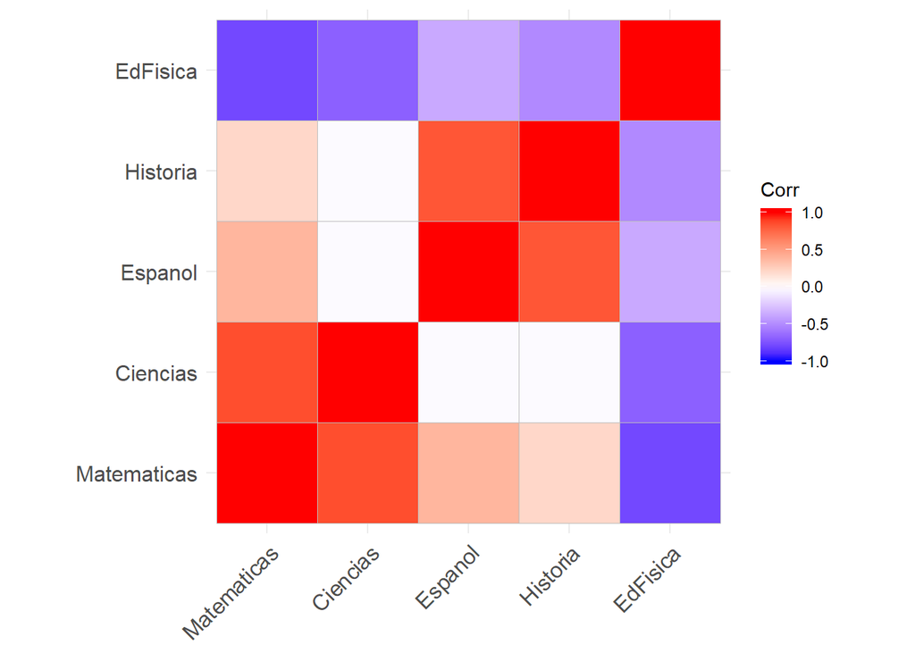

```r
# Explore otras opciones: corrplot(c, method = "number") / corrplot(c, method = "square") / corrplot(c, method = "ellipse") / corrplot(c, method = "pie") / corrplot(c, method = "shade") / corrplot(c, method = "shade", type = "upper") / corrplot(c, method = "shade", type = "low")

# Usaremos funciones del paquete ggcorrplot
ggcorrplot(c)
```

```r
# Explore: ggcorrplot(c, method = "circle") / ggcorrplot(c, method = "square", lab = TRUE) /

# Se trabaja con DataFrame

c_df <- correlate(estudiantes) # Usa el paquete corrr
```

```
##
## Correlation method: 'pearson'
## Missing treated using: 'pairwise.complete.obs'
```

```r
class(c_df)
```

```
## [1] "cor_df"     "tbl_df"     "tbl"        "data.frame"
```

```r
c
```

```
##             Matematicas Ciencias Espanol Historia EdFisica
## Matematicas        1.00     0.85    0.38     0.21    -0.79
## Ciencias           0.85     1.00   -0.02    -0.02    -0.69
## Espanol            0.38    -0.02    1.00     0.82    -0.37
## Historia           0.21    -0.02    0.82     1.00    -0.51
## EdFisica          -0.79    -0.69   -0.37    -0.51     1.00
```

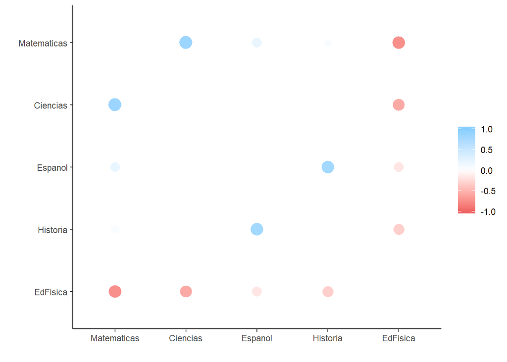

```r
rplot(c_df)
```

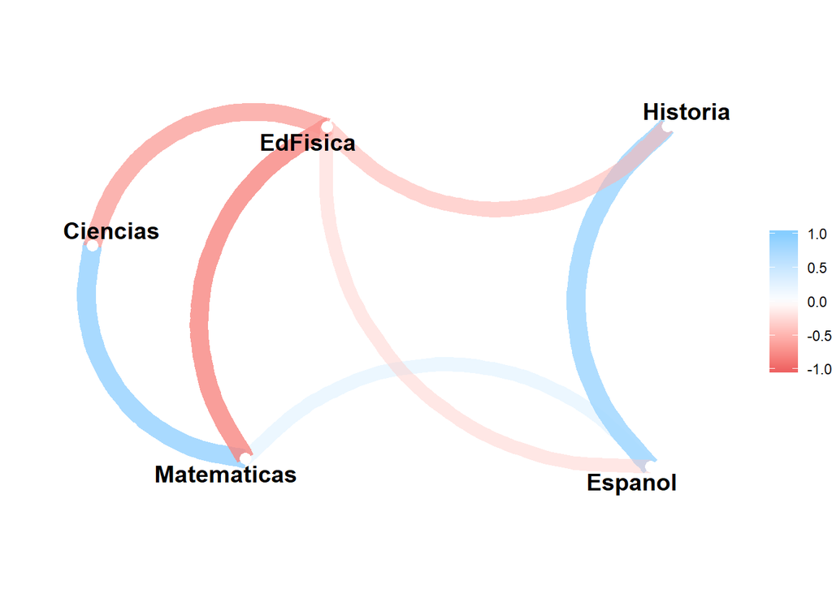

```r
# Explore: rplot(cor_df, colours = c("yellow","white","red")) / rplot(cor_df, shape = 2,  colours = c("yellow","white","red")) / rplot(cor_df, shape = 2,  colours = c("yellow","white","red"), print_cor = TRUE) /

# Otro gráfico bonito
network_plot(c_df) # Paquete corrr
```

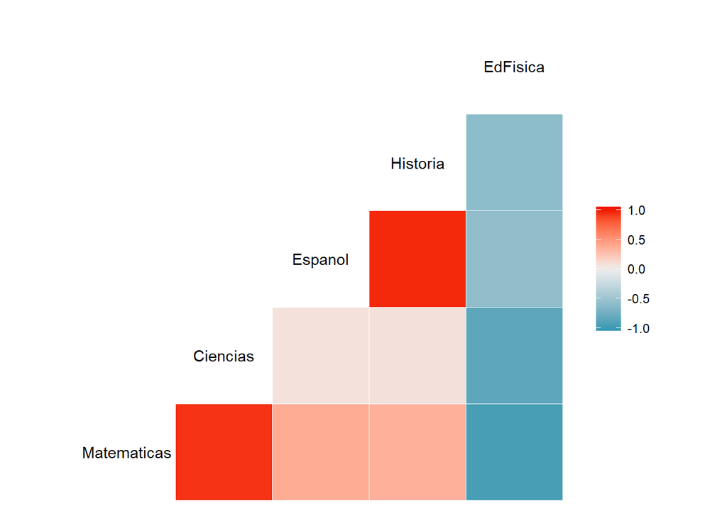

```r
ggcorr(c) # Paquete GGally
```

```r
# Explore ggcorr(c, label = TRUE, lavel_alpha = TRUE) /
```

# Resolviendo el ejercicio paso a paso con ACP

En primer lugar se resta a cada valor la media de la variable a la que pertenece. Con esto se consigue centralizar las variables y que su media sea 0

```r
datos_centrados <- estudiantes
datos_centrados$Matematicas <- estudiantes$Matematicas - mean(estudiantes$Matematicas)
datos_centrados$Ciencias <- estudiantes$Ciencias - mean(estudiantes$Ciencias)
datos_centrados$Espanol <- estudiantes$Espanol - mean(estudiantes$Espanol)
datos_centrados$Historia <- estudiantes$Historia - mean(estudiantes$Historia)
datos_centrados$EdFisica <- estudiantes$EdFisica - mean(estudiantes$EdFisica)


datos_centrados
```

|  | Matematicas | Ciencias | Espanol | Historia | EdFisica |
| --- | --- | --- | --- | --- | --- |
| Lucia | 0.21 | -1.15 | 1.46 | 0.7 | 0.58 |
| Pedro | 0.71 | 1.75 | -0.44 | -0.9 | -0.42 |
| Ines | 0.81 | 1.55 | 0.26 | 0.1 | 0.08 |
| Luis | -1.79 | -1.15 | -1.24 | -0.9 | 1.58 |
| Andres | -0.79 | -1.65 | 0.06 | 1.0 | -0.12 |
| Ana | 1.01 | 1.95 | -0.04 | 0.1 | -0.92 |
| Carlos | -0.49 | -1.25 | 0.46 | 1.1 | -0.22 |
| Jose | 1.11 | 2.05 | -0.24 | 0.1 | -1.42 |
| Sonia | -0.79 | -1.65 | -1.24 | -2.4 | 1.28 |
| Maria | 0.01 | -0.45 | 0.96 | 1.1 | -0.42 |

|  | Matematicas <dbl> | Ciencias <dbl> | Espanol <dbl> | Historia <dbl> | EdFisica <dbl> |
| --- | --- | --- | --- | --- | --- |
| Lucia | 0.21 | -1.15 | 1.46 | 0.7 | 0.58 |
| Pedro | 0.71 | 1.75 | -0.44 | -0.9 | -0.42 |
| Ines | 0.81 | 1.55 | 0.26 | 0.1 | 0.08 |
| Luis | -1.79 | -1.15 | -1.24 | -0.9 | 1.58 |
| Andres | -0.79 | -1.65 | 0.06 | 1.0 | -0.12 |
| Ana | 1.01 | 1.95 | -0.04 | 0.1 | -0.92 |
| Carlos | -0.49 | -1.25 | 0.46 | 1.1 | -0.22 |
| Jose | 1.11 | 2.05 | -0.24 | 0.1 | -1.42 |
| Sonia | -0.79 | -1.65 | -1.24 | -2.4 | 1.28 |
| Maria | 0.01 | -0.45 | 0.96 | 1.1 | -0.42 |

1-10 of 10 rows

# Matriz de covarianzas

Nos permite saber cómo se comporta una variable en función de lo que hace otra variable, evidenciando así la tendencia. Es decir, cuando X sube ¿Cómo se comporta Y? Así pues, la covarianza puede tomar los siguiente valores:

Covarianza (X,Y) es menor que cero cuando “X” sube e “Y” baja. Hay una relación negativa.

Covarianza (X,Y) es mayor que cero cuando “X” sube e “Y” sube. Hay una relación positiva.

Covarianza (X,Y) es igual que cero cuando “X” sube e “Y” baja. No hay relación existente entre las variables “X” e “Y”.

```r
matriz_cov <- cov(datos_centrados)
matriz_cov
```

```
##             Matematicas    Ciencias     Espanol    Historia   EdFisica
## Matematicas   0.9054444  1.30833333  0.31488889  0.22111111 -0.6953333
## Ciencias      1.3083333  2.59166667 -0.02777778 -0.03888889 -1.0277778
## Espanol       0.3148889 -0.02777778  0.74044444  0.79222222 -0.2920000
## Historia      0.2211111 -0.03888889  0.79222222  1.25777778 -0.5288889
## EdFisica     -0.6953333 -1.02777778 -0.29200000 -0.52888889  0.8617778
```

Dado que la matriz de covarianzas es cuadrada, se pueden obtener sus correspondientes eigenvectors y eigenvalues

```r
eigen <- eigen(matriz_cov)
eigen
```

```
## eigen() decomposition
## $values
## [1] 3.887010440 1.992682789 0.300906107 0.167944893 0.008566882
##
## $vectors
##            [,1]       [,2]        [,3]        [,4]       [,5]
## [1,] -0.4554991 -0.0301873 -0.47296282 -0.39587804  0.6412457
## [2,] -0.7730822  0.3366382  0.04147109  0.49953935 -0.1943173
## [3,] -0.1117975 -0.5349732 -0.62844982  0.02458048 -0.5529481
## [4,] -0.1416005 -0.7479026  0.35163283  0.39973889  0.3703433
## [5,]  0.4028835  0.2005213 -0.50595602  0.65828993  0.3288450
```

Los eigenvectors ordenados de mayor a menor eigenvalues se corresponden con las componentes principales.

Una vez obtenidos los eigenvectors (componentes principales) se calcula el valor que toma cada componente para cada observación en función de las variables originales (principal component scores). Para ello, simplemente se tienen que multiplicar los eigenvectors transpuestos por los datos originales centrados y también transpuestos.

```r
# Producto matricial
pc_scores <- t(eigen$vectors) %*% t(datos_centrados)
rownames(pc_scores) <- c("PC1", "PC2", "PC3", "PC4", "PC5")

# Se vuelve a transponer para que los datos estén en modo tabla
t(pc_scores)
```

```
##                PC1        PC2         PC3          PC4           PC5
## Lucia   0.76471745 -1.5817637 -1.11186219  0.039908252  0.0007926494
## Pedro  -1.66887794  1.3919656 -0.09067929 -0.053941739 -0.1128975404
## Ines   -1.57822841  0.2994960 -0.48752985  0.552652786  0.1377925976
## Luis    2.60701317  1.3202040  0.46230941  0.784004734 -0.0524431575
## Andres  1.43877557 -1.3356687  0.67985389 -0.189277341  0.1117444886
## Ana    -2.34790534  0.3880845  0.12895699  0.007628838  0.0253542859
## Carlos  0.89372557 -1.5189012  0.38893244 -0.124247926  0.0093618642
## Jose   -2.64984571  0.4254636  0.46447580 -0.316066094  0.0162142654
## Sonia   2.62959083  2.1833951 -0.40705140 -0.658738298  0.0317927290
## Maria  -0.08896518 -1.5722752 -0.02740580 -0.041923214 -0.1677121823
```

```r
PCA_data <- princomp(estudiantes ,cor="False")
PCA_data$loadings[,1:5]
```

```
##                 Comp.1     Comp.2      Comp.3      Comp.4     Comp.5
## Matematicas  0.4554991  0.0301873  0.47296282  0.39587804  0.6412457
## Ciencias     0.7730822 -0.3366382 -0.04147109 -0.49953935 -0.1943173
## Espanol      0.1117975  0.5349732  0.62844982 -0.02458048 -0.5529481
## Historia     0.1416005  0.7479026 -0.35163283 -0.39973889  0.3703433
## EdFisica    -0.4028835 -0.2005213  0.50595602 -0.65828993  0.3288450
```

```r
eigen$vectors
```

```
##            [,1]       [,2]        [,3]        [,4]       [,5]
## [1,] -0.4554991 -0.0301873 -0.47296282 -0.39587804  0.6412457
## [2,] -0.7730822  0.3366382  0.04147109  0.49953935 -0.1943173
## [3,] -0.1117975 -0.5349732 -0.62844982  0.02458048 -0.5529481
## [4,] -0.1416005 -0.7479026  0.35163283  0.39973889  0.3703433
## [5,]  0.4028835  0.2005213 -0.50595602  0.65828993  0.3288450
```

```r
# Se puede notar con producto punto que las componentes principales son vectores ortogonales

round(PCA_data$loadings[, 1] %*% PCA_data$loadings[, 2], 2)
```

```
##      [,1]
## [1,]    0
```

# Calculamos PCA usando el comando base prcomp

```r
pca <- prcomp(estudiantes, scale = TRUE)
names(pca)
```

```
## [1] "sdev"     "rotation" "center"   "scale"    "x"
```

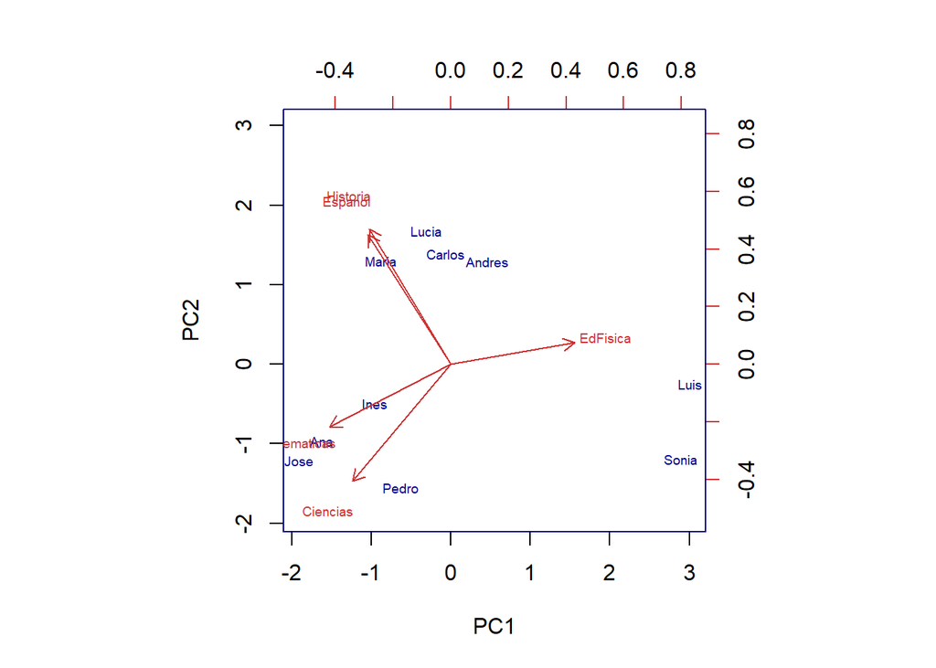

```r
biplot(x = pca, scale = 0, cex = 0.6, col = c("blue4", "brown3"))
```

```r
pca$sdev
```

```
## [1] 1.70095552 1.27618589 0.58872409 0.35016062 0.09429419
```

```r
pca
```

```
## Standard deviations (1, .., p=5):
## [1] 1.70095552 1.27618589 0.58872409 0.35016062 0.09429419
##
## Rotation (n x k) = (5 x 5):
##                    PC1         PC2         PC3         PC4        PC5
## Matematicas -0.5266440 -0.27049630  0.43820071 -0.26121779 -0.6238776
## Ciencias    -0.4249362 -0.50807221  0.04049491  0.67362724  0.3253895
## Espanol     -0.3591470  0.56208159  0.56227583 -0.07008647  0.4837473
## Historia    -0.3526975  0.58648985 -0.39418032  0.44664495 -0.4204335
## EdFisica     0.5373018  0.09374599  0.57862603  0.52305619 -0.3067941
```

```r
prop_varianza <- pca$sdev^2 / sum(pca$sdev^2) # se calcula la proporción de la varianza
prop_varianza
```

```
## [1] 0.578649935 0.325730085 0.069319210 0.024522492 0.001778279
```

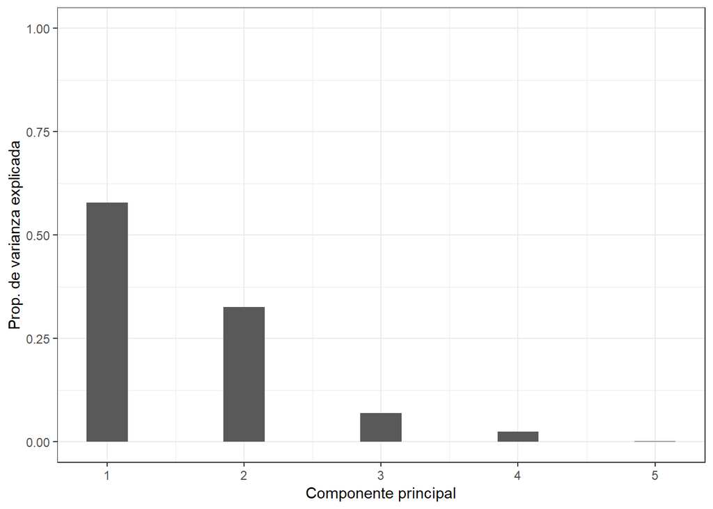

```r
ggplot(data = data.frame(prop_varianza, pc = 1:5),
       aes(x = pc, y = prop_varianza)) +
  geom_col(width = 0.3) +
  scale_y_continuous(limits = c(0,1)) +
  theme_bw() +
  labs(x = "Componente principal",
       y = "Prop. de varianza explicada")
```

## Se puede ver esta varianza proporcional, como una variación acumulada

```r
prop_varianza_acum <- cumsum(prop_varianza)
prop_varianza_acum
```

```
## [1] 0.5786499 0.9043800 0.9736992 0.9982217 1.0000000
```

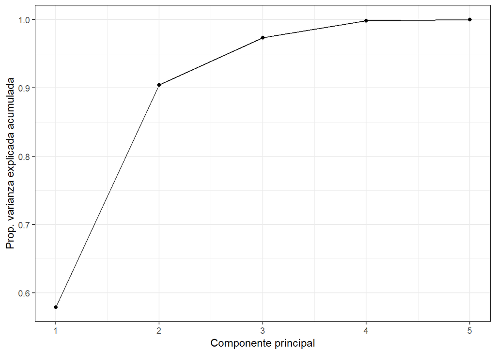

```r
ggplot(data = data.frame(prop_varianza_acum, pc = 1:5),
       aes(x = pc, y = prop_varianza_acum, group = 1)) +
  geom_point() +
  geom_line() +
  theme_bw() +
  labs(x = "Componente principal",
       y = "Prop. varianza explicada acumulada")
```

# Usando FactoMiner

El siguiente ejemplo, muestra como hacer un PCA usando el paquete FactoMiner

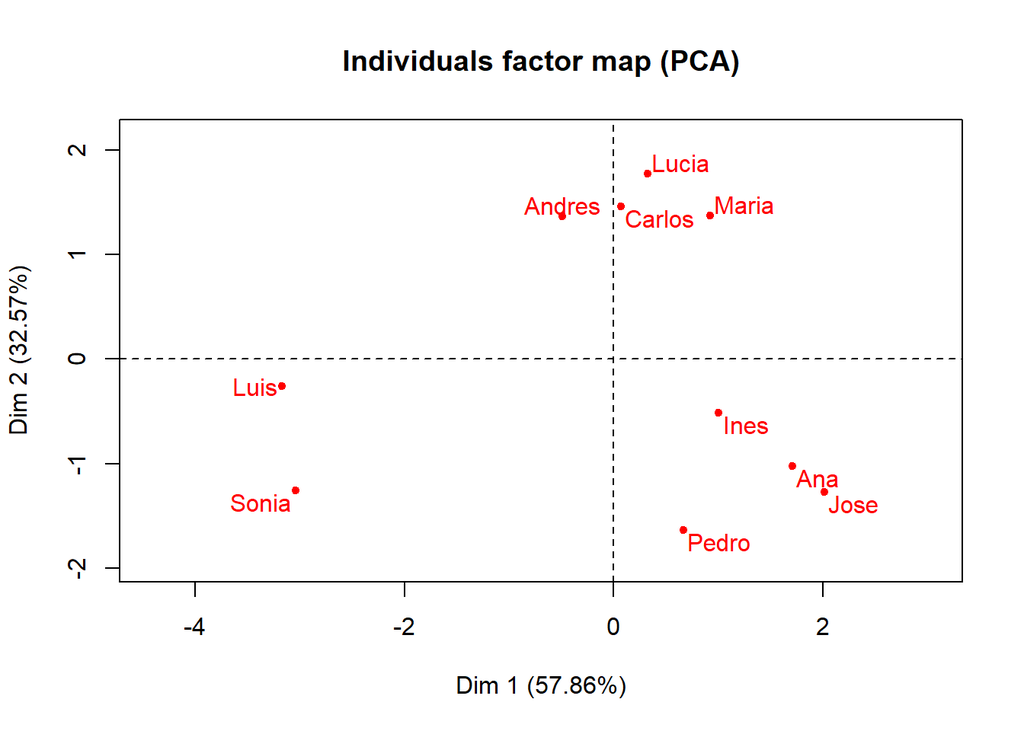

```r
pca_est <- PCA(estudiantes, scale.unit=TRUE, ncp=5, graph = FALSE)


# Graficamos plano principal y círculo de correlaciones por separado

plot(pca_est, axes=c(1, 2), choix="ind", col.ind="red",new.plot=TRUE)
```

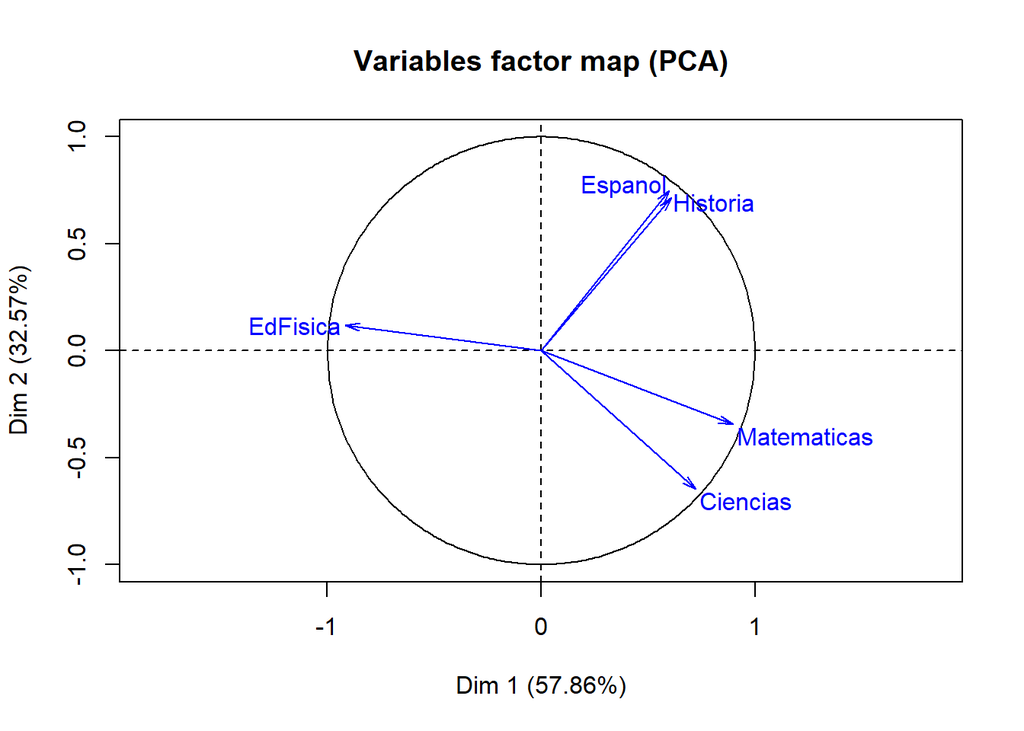

```r
plot(pca_est, axes=c(1, 2), choix="var", col.var="blue",new.plot=TRUE)
```

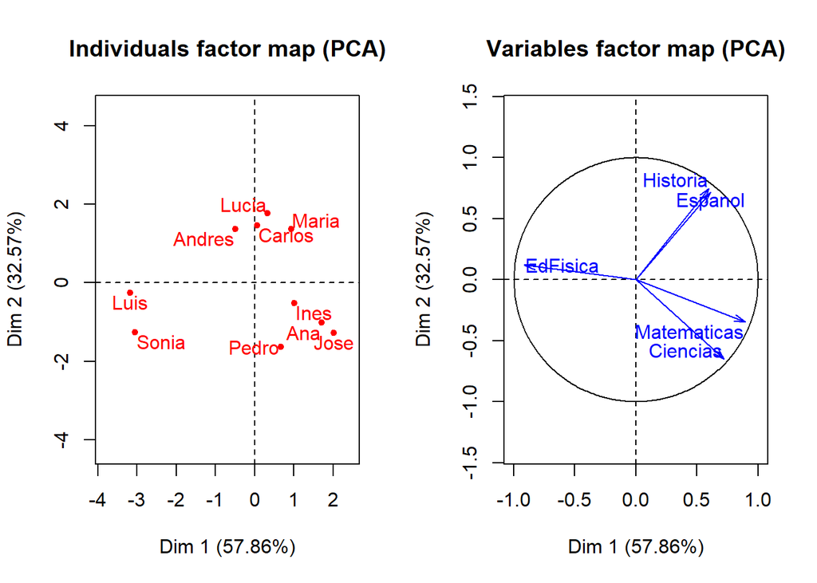

```r
# Graficamos plano principal y círculo de correlaciones juntos

par(mfrow=c(1,2))
plot(pca_est, axes=c(1, 2), choix="ind", col.ind="red",new.plot=TRUE)
plot(pca_est, axes=c(1, 2), choix="var", col.var="blue",new.plot=TRUE)
```

# Individuos y variables mal representados

```r
importaciones <- read.csv("Datos/ImportacionesMexico.csv", sep = ";", dec = ",", header = T,row.names = 1)
head(estudiantes)
```

|  | Matematicas | Ciencias | Espanol | Historia | EdFisica |
| --- | --- | --- | --- | --- | --- |
| Lucia | 7.0 | 6.5 | 9.2 | 8.6 | 8.0 |
| Pedro | 7.5 | 9.4 | 7.3 | 7.0 | 7.0 |
| Ines | 7.6 | 9.2 | 8.0 | 8.0 | 7.5 |
| Luis | 5.0 | 6.5 | 6.5 | 7.0 | 9.0 |
| Andres | 6.0 | 6.0 | 7.8 | 8.9 | 7.3 |
| Ana | 7.8 | 9.6 | 7.7 | 8.0 | 6.5 |

|  | Matematicas <dbl> | Ciencias <dbl> | Espanol <dbl> | Historia <dbl> | EdFisica <dbl> |
| --- | --- | --- | --- | --- | --- |
| Lucia | 7.0 | 6.5 | 9.2 | 8.6 | 8.0 |
| Pedro | 7.5 | 9.4 | 7.3 | 7.0 | 7.0 |
| Ines | 7.6 | 9.2 | 8.0 | 8.0 | 7.5 |
| Luis | 5.0 | 6.5 | 6.5 | 7.0 | 9.0 |
| Andres | 6.0 | 6.0 | 7.8 | 8.9 | 7.3 |
| Ana | 7.8 | 9.6 | 7.7 | 8.0 | 6.5 |

6 rows

```r
str(estudiantes)
```

```
## 'data.frame':    10 obs. of  5 variables:
##  $ Matematicas: num  7 7.5 7.6 5 6 7.8 6.3 7.9 6 6.8
##  $ Ciencias   : num  6.5 9.4 9.2 6.5 6 9.6 6.4 9.7 6 7.2
##  $ Espanol    : num  9.2 7.3 8 6.5 7.8 7.7 8.2 7.5 6.5 8.7
##  $ Historia   : num  8.6 7 8 7 8.9 8 9 8 5.5 9
##  $ EdFisica   : num  8 7 7.5 9 7.3 6.5 7.2 6 8.7 7
```

## Aplicamos PCA

```r
acp_mexico<-PCA(importaciones, scale.unit=TRUE, ncp=5, graph = FALSE)

cos2.ind<-(acp_mexico$ind$cos2[,1] + acp_mexico$ind$cos2[,2])*100
cos2.ind
```

```
##       1979       1980       1981       1982       1983       1984
## 96.1000354 86.9743777 80.6523653 70.7456314 65.6042706 85.9034700
##       1985       1986       1987       1988
## 75.1710823 81.9688762  4.9898384  0.8100985
```

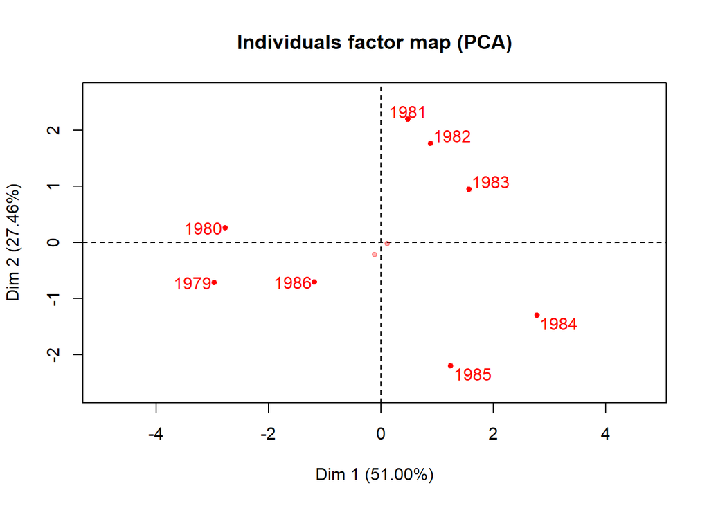

```r
# Grafica los individuos que tengan cos2 >= 0.1 (10%)
plot(acp_mexico, axes=c(1, 2), choix="ind",col.ind="red",new.plot=TRUE,select="cos2 0.1")
```

## Análogamente se hace el mismo análisi para las variables

```r
cos2.var<-(acp_mexico$var$cos2[,1] + acp_mexico$var$cos2[,2])*100
cos2.var
```

```
##  Costa.Rica El.Salvador   Guatemala    Honduras   Nicaragua      Panama
##    73.87060    89.22701    71.89417    67.23724    77.57747    90.95865
```

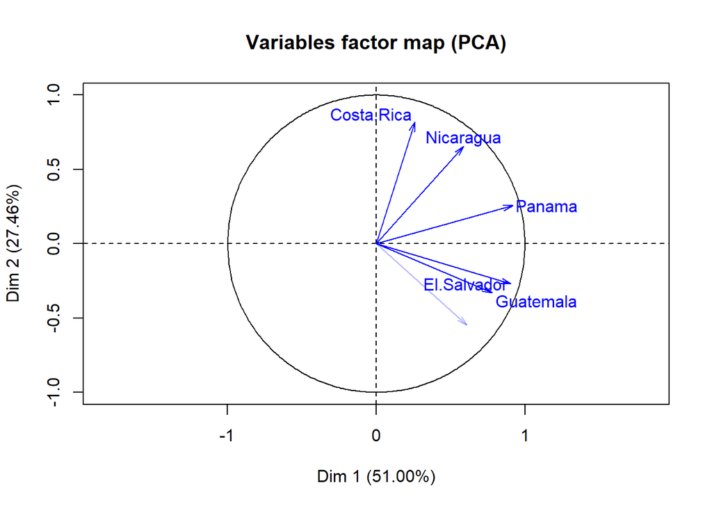

```r
# Grafica las variables que tengan cos2 >= 0.7 (70%)
plot(acp_mexico, axes=c(1, 2), choix="var",col.var="blue",new.plot=TRUE,select="cos2 0.7")
```

# Interpretación con Gráficos Tipo Estrella (Tipo Araña, Tipo Radar)

```r
modelo <- hclust(dist(importaciones),method= "ward")
```

```
## The "ward" method has been renamed to "ward.D"; note new "ward.D2"
```

```r
centros<-centers.hclust(importaciones,modelo,nclust=3,use.median=FALSE)
centros
```

```
##      Costa.Rica El.Salvador Guatemala Honduras Nicaragua   Panama
## [1,]   66.84000    50.18000     65.44    24.92     11.30  63.2200
## [2,]   90.86667    67.83333    106.50    22.50    147.90 130.5667
## [3,]   54.20000    93.45000    190.15    41.05     54.45 119.6000
```

```r
rownames(centros)<-c("Cluster 1","Cluster 2","Cluster 3")
centros<-as.data.frame(centros)
maximos<-apply(centros,2,max)
minimos<-apply(centros,2,min)
centros<-rbind(minimos,centros)
centros<-rbind(maximos,centros)
centros
```

|  | Costa.Rica | El.Salvador | Guatemala | Honduras | Nicaragua | Panama |
| --- | --- | --- | --- | --- | --- | --- |
| 1 | 90.86667 | 93.45000 | 190.15 | 41.05 | 147.90 | 130.5667 |
| 11 | 54.20000 | 50.18000 | 65.44 | 22.50 | 11.30 | 63.2200 |
| Cluster 1 | 66.84000 | 50.18000 | 65.44 | 24.92 | 11.30 | 63.2200 |
| Cluster 2 | 90.86667 | 67.83333 | 106.50 | 22.50 | 147.90 | 130.5667 |
| Cluster 3 | 54.20000 | 93.45000 | 190.15 | 41.05 | 54.45 | 119.6000 |

|  | Costa.Rica <dbl> | El.Salvador <dbl> | Guatemala <dbl> | Honduras <dbl> | Nicaragua <dbl> | Panama <dbl> |
| --- | --- | --- | --- | --- | --- | --- |
| 1 | 90.86667 | 93.45000 | 190.15 | 41.05 | 147.90 | 130.5667 |
| 11 | 54.20000 | 50.18000 | 65.44 | 22.50 | 11.30 | 63.2200 |
| Cluster 1 | 66.84000 | 50.18000 | 65.44 | 24.92 | 11.30 | 63.2200 |
| Cluster 2 | 90.86667 | 67.83333 | 106.50 | 22.50 | 147.90 | 130.5667 |
| Cluster 3 | 54.20000 | 93.45000 | 190.15 | 41.05 | 54.45 | 119.6000 |

5 rows

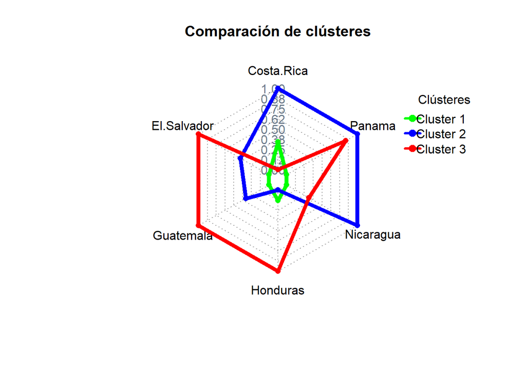

```r
radarchart(centros,maxmin=TRUE,axistype=4,axislabcol="slategray4",
           centerzero=FALSE,seg=8,cglcol="gray67",
           pcol=c("green","blue","red"),
           plty=1,
           plwd=5,
           title="Comparación de clústeres")

legenda <-legend(1.5,1, legend=c("Cluster 1","Cluster 2","Cluster 3"),
                 seg.len=-1.4,
                 title="Clústeres",
                 pch=21,
                 bty="n" ,lwd=3, y.intersp=1, horiz=FALSE,
                 col=c("green","blue","red"))
```